# Finetuning for Text Classification

# Fine-Tuning GPT-2 on the IMDB Dataset

```python
!pip install tensorflow
```

[output not shown]

```python
!pip install tiktoken
from importlib.metadata import version

pkgs = ["matplotlib",
        "numpy",
        "tiktoken",
        "torch",
        "tensorflow", # For OpenAI's pretrained weights
        "pandas"      # Dataset loading
       ]
for p in pkgs:
    print(f"{p} version: {version(p)}")
```

```
matplotlib version: 3.7.3
numpy version: 2.0.2
tiktoken version: 0.8.0
torch version: 2.3.0+cu121
tensorflow version: 2.18.0
pandas version: 2.0.3
```

[figure not shown]

## 6.1 Different categories of finetuning

- No code in this section
- The most common ways to finetune language models are instruction-finetuning and classification finetuning
- Instruction-finetuning, depicted below, is the topic of the next chapter

[figure not shown]

- Classification finetuning, the topic of this chapter, is a procedure you may already be familiar with if you have a background in machine learning -- it's similar to training a convolutional network to classify handwritten digits, for example
- In classification finetuning, we have a specific number of class labels (for example, "spam" and "not spam") that the model can output
- A classification finetuned model can only predict classes it has seen during training (for example, "spam" or "not spam"), whereas an instruction-finetuned model can usually perform many tasks
- We can think of a classification-finetuned model as a very specialized model; in practice, it is much easier to create a specialized model than a generalist model that performs well on many different tasks

[figure not shown]

## 6.2 Preparing the dataset

[figure not shown]

```python
# from google.colab import drive
# drive.mount('/content/drive')
```

```python
# import sys
# import os

# # Update this path to the folder where your files are stored
# project_path = '/content/drive/My Drive/Colab Notebooks/GenAI_Utku/Week-5/Classification FineTune'

# # Add the project path to the system path to access your files
# sys.path.append(project_path)
# os.chdir(project_path)
```

```python
# Load CSV files into Google Colab notebook and assign them to train_df, validation_df, and test_df

import pandas as pd

# Load the CSV files
train_df = pd.read_csv('train.csv')
validation_df = pd.read_csv('validation.csv')
test_df = pd.read_csv('test.csv')
```

```python
train_df.shape
```

```
(35000, 2)
```

```python
validation_df.shape
```

```
(5000, 2)
```

```python
test_df.shape
```

```
(10000, 2)
```

```python
print(train_df.columns)
```

```
Index(['text', 'label'], dtype='object')
```

## 6.3 Creating data loaders

- Note that the text messages have different lengths; if we want to combine multiple training examples in a batch, we have to either
  1. truncate all messages to the length of the shortest message in the dataset or batch
  2. pad all messages to the length of the longest message in the dataset or batch
- We choose option 2 and **pad all messages to the longest message in the dataset**
- For that, we use `<|endoftext|>` as a padding token

[figure not shown]

# gpt2

# tokenizes the text using the GPT-2 tokenizer from tiktoken

```python
#!pip install tiktoken
import tiktoken

tokenizer = tiktoken.get_encoding("gpt2")
print(tokenizer.encode("<|endoftext|>", allowed_special={"<|endoftext|>"}))
```

```
[50256]
```

- The `IMDBDataset` class below **identifies the longest sequence in the training dataset** and adds the padding token to the others to match that sequence length
- The IMDBDataset class preprocesses text data into padded sequences of token IDs, making it compatible with PyTorch's DataLoader for batching. It provides sequence padding for consistency in input length, making it ideal for NLP tasks that require fixed-length inputs.

```python
import torch
from torch.utils.data import Dataset


class IMDBDataset(Dataset):
    # max_length: Optional, specifies the maximum sequence length for all texts. If not provided, the class calculates the longest sequence and uses it as the max_length.
    def __init__(self, csv_file, tokenizer, max_length=None, pad_token_id=50256):
        self.data = pd.read_csv(csv_file)

        # Pre-tokenize texts
        # Encodes each text string using the provided tokenizer, converting each text into a list of token IDs.
        # The resulting self.encoded_texts is a list where each item is a list of integers.
        self.encoded_texts = [
            tokenizer.encode(text) for text in self.data["text"]
        ]

        if max_length is None:
            self.max_length = self._longest_encoded_length()
        else:
            self.max_length = max_length
            # Truncate sequences if they are longer than max_length
            self.encoded_texts = [
                encoded_text[:self.max_length]
                for encoded_text in self.encoded_texts
            ]


        # Pad sequences to the longest sequence
        # Pads each encoded sequence to self.max_length by appending pad_token_id as many times as needed.
        self.encoded_texts = [
            encoded_text + [pad_token_id] * (self.max_length - len(encoded_text))
            for encoded_text in self.encoded_texts
        ]

    # This method allows access to individual data points by their index.
    # encoded: Retrieves the encoded (and padded/truncated) token list for the text at the specified index.
    # label: Retrieves the corresponding label from self.data.
    # Converts both the encoded sequence and label into PyTorch tensors for compatibility with PyTorch models.
    def __getitem__(self, index):
        encoded = self.encoded_texts[index]
        label = self.data.iloc[index]["label"]
        return (
            torch.tensor(encoded, dtype=torch.long),
            torch.tensor(label, dtype=torch.long)
        )


    # Returns the total number of samples in the dataset, equivalent to the number of rows in the loaded CSV.
    def __len__(self):
        return len(self.data)

    # Loops through each encoded text sequence to find the longest sequence length.
    # Updates max_length to the longest observed sequence length,
    # which is then used for padding all sequences to a consistent length if max_length was not provided during initialization.
    def _longest_encoded_length(self):
        max_length = 0
        for encoded_text in self.encoded_texts:
            encoded_length = len(encoded_text)
            if encoded_length > max_length:
                max_length = encoded_length
        return max_length
```

The IMDBDataset class loads data from the CSV files, tokenizes the text using the GPT-2 tokenizer from tiktoken, and allows us to pad or truncate the sequences to a uniform length determined by either the longest sequence or a predefined maximum length. This ensures each input tensor is of the same size, which is **necessary to create the batches in the training data loader we implement**

```python
train_dataset = IMDBDataset(
    csv_file="train.csv",
    max_length=None,
    tokenizer=tokenizer
)

print(train_dataset.max_length)
```

```
3097
```

3097 is showing that the longest sequence contains no more than 3097 tokens.

The model can handle sequences of up to 1,024 tokens, given its context length limit.

If your dataset includes longer texts, you can pass max_length=1024 when creating the training dataset in the preceding code to ensure that the data does not exceed the **model’s supported input (context) length**.

```python
train_dataset = IMDBDataset(
    csv_file="train.csv",
    max_length=1024,
    tokenizer=tokenizer
)

print(train_dataset.max_length)
```

```
1024
```

```python
val_dataset = IMDBDataset(
    csv_file="validation.csv",
    max_length=train_dataset.max_length,
    tokenizer=tokenizer
)

test_dataset = IMDBDataset(
    csv_file="test.csv",
    max_length=train_dataset.max_length,
    tokenizer=tokenizer
)
```

```python
print(val_dataset.max_length)
```

```
1024
```

```python
print(test_dataset.max_length)
```

```
1024
```

```python
print(len(train_dataset))
```

```
35000
```

```python
# Access an individual item to see the structure of a sample (input sequence and label).
print(train_dataset[0])  # Inspect the first sample
```

```
(tensor([  464,   691,  1738,  ..., 50256, 50256, 50256]), tensor(0))
```

```python
# You can look at the shape of the encoded text sequence and label by examining individual samples.
sample_data, sample_label = train_dataset[0]
print("Encoded Text Shape:", sample_data.shape)
print("Label:", sample_label)
```

```
Encoded Text Shape: torch.Size([1024])
Label: tensor(0)
```

```python
# You can check the attributes of train_dataset directly, such as max_length and encoded_texts.
print("Max Length:", train_dataset.max_length)
print("First Encoded Text:", train_dataset.encoded_texts[0])
```

```
Max Length: 1024
First Encoded Text: [464, 691, 1738, 314, 2497, 366, 2484, 25817, 1, 373, 326, 340, 468, 412, 28716, 2574, 268, 32994, 287, 340, 13, 1375, 338, 17144, 355, 1464, 11, 475, 673, 5341, 1218, 277, 2509, 284, 3756, 582, 8662, 42630, 13, 632, 338, 257, 26246, 11, 780, 673, 468, 517, 2223, 9889, 621, 673, …
```

- Next, we use the dataset to instantiate the **data loaders**

[figure not shown]

**By increasing the batch_size in your DataLoader, you reduce the total number of batches** (i.e., len(train_loader)) per epoch. Here’s a quick breakdown:

- Increasing the batch_size reduces the number of iterations needed to complete an epoch, as more data samples are processed in each batch.
- For example, if you have 10,000 samples in your dataset, a batch_size of 8 results in 1,250 steps per epoch, whereas a batch_size of 128 would reduce it to about 78 steps per epoch.

You can adjust batch_size to a larger value like 128 (or whatever your GPU memory allows) to reduce the training time by lowering the number of steps per epoch. This will affect the frequency of your print statements if you continue to use eval_freq.

# I use batch_size = 8 here

```python
from torch.utils.data import DataLoader

num_workers = 0
batch_size = 8

torch.manual_seed(123)

train_loader = DataLoader(
    dataset=train_dataset,
    batch_size=batch_size,
    # Shuffles the dataset at the beginning of each epoch, ensuring that batches vary between epochs, which can help the model generalize better.
    shuffle=True,
    num_workers=num_workers,
    drop_last=True,
)

val_loader = DataLoader(
    dataset=val_dataset,
    batch_size=batch_size,
    num_workers=num_workers,
    drop_last=False,
)

test_loader = DataLoader(
    dataset=test_dataset,
    batch_size=batch_size,
    num_workers=num_workers,
    drop_last=False,
)
# Dropping the last batch ensures that all training batches are the same size.
# This is especially useful when using batch normalization or other operations that depend on batch size.
# However, this is set to False for validation and testing since you typically want to evaluate on all samples.
```

```python
train_loader
```

```
<torch.utils.data.dataloader.DataLoader at 0x7f81dd941d20>
```

- As a verification step, we iterate through the data loaders and ensure that the **batches contain 8 training examples each, where each training example consists of 1024 tokens**

```python
print("Train loader:")
for input_batch, target_batch in train_loader:
    pass

print("Input batch dimensions:", input_batch.shape)
print("Label batch dimensions", target_batch.shape)
```

```
Train loader:
Input batch dimensions: torch.Size([8, 1024])
Label batch dimensions torch.Size([8])
```

- Lastly, let's print the total number of batches in each dataset

# 35000/8=4375

```python
print(f"{len(train_loader)} training batches")
print(f"{len(val_loader)} validation batches")
print(f"{len(test_loader)} test batches")
```

```
4375 training batches
625 validation batches
1250 test batches
```

## 6.4 Initializing a model with pretrained weights

- In this section, we initialize the pretrained model

[figure not shown]

# CHOOSE_MODEL = "gpt2-small (124M)"

This code snippet configures settings for a language model, specifically a variant of GPT-2, based on the model size specified in CHOOSE_MODEL. It ensures compatibility between the model's context length and the maximum sequence length in the dataset (train_dataset).

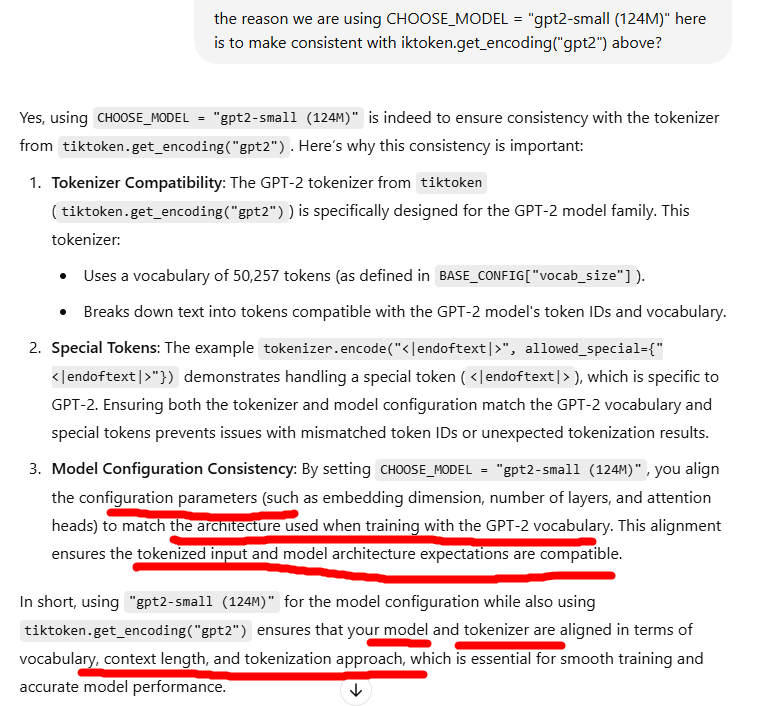

```python
CHOOSE_MODEL = "gpt2-small (124M)"
INPUT_PROMPT = "Every effort moves"

BASE_CONFIG = {
    "vocab_size": 50257,     # Vocabulary size
    "context_length": 1024,  # Context length
    "drop_rate": 0.0,        # Dropout rate
    # Indicates whether the query, key, and value matrices in the transformer layers should have bias terms.
    # Setting qkv_bias=True applies this bias, which can enhance model flexibility.
    "qkv_bias": True         # Query-key-value bias
}

# emb_dim: The embedding dimension of the model.
# n_layers: The number of transformer layers (stacked blocks) in the model.
# n_heads: The number of attention heads in each layer.
model_configs = {
    "gpt2-small (124M)": {"emb_dim": 768, "n_layers": 12, "n_heads": 12},
    "gpt2-medium (355M)": {"emb_dim": 1024, "n_layers": 24, "n_heads": 16},
    "gpt2-large (774M)": {"emb_dim": 1280, "n_layers": 36, "n_heads": 20},
    "gpt2-xl (1558M)": {"emb_dim": 1600, "n_layers": 48, "n_heads": 25},
}

BASE_CONFIG.update(model_configs[CHOOSE_MODEL])

# This line checks if the maximum sequence length in train_dataset (train_dataset.max_length) is within the model’s context_length.
assert train_dataset.max_length <= BASE_CONFIG["context_length"], (
    f"Dataset length {train_dataset.max_length} exceeds model's context "
    f"length {BASE_CONFIG['context_length']}. Reinitialize data sets with "
    f"`max_length={BASE_CONFIG['context_length']}`"
)
```

```python
!ls
```

```
assignment_3_finetune_gtp2_classification.ipynb  test.csv
gpt_download.py					 train.csv
previous_chapters.py				 validation.csv
```

This code downloads pre-trained weights for the selected GPT-2 model, initializes a new GPT model instance, loads the downloaded weights into the model, and prepares it for inference.

This code:

- Extracts the model size from CHOOSE_MODEL.
- Downloads pre-trained GPT-2 weights for that specific model size.
- Initializes a GPTModel with the correct configuration.
- Loads the pre-trained weights into the model.
- Sets the model to evaluation mode, making it ready for inference.

This approach allows you to use the pre-trained GPT-2 model directly, without training from scratch, for tasks such as text generation or language understanding.

```python
from gpt_download import download_and_load_gpt2
from previous_chapters import GPTModel, load_weights_into_gpt

# CHOOSE_MODEL is set to a string like "gpt2-small (124M)", so this line isolates "124M" (the model size) by splitting the string and stripping off the parentheses.
model_size = CHOOSE_MODEL.split(" ")[-1].lstrip("(").rstrip(")")

# settings: A configuration dictionary containing any model-specific settings.
# params: The pre-trained weights (parameters) of the model, which are loaded into the initialized model in the next step.
settings, params = download_and_load_gpt2(model_size=model_size, models_dir="gpt2")

# Creates an instance of GPTModel with BASE_CONFIG,
# which includes parameters like embedding dimensions, number of layers, and attention heads (based on the configuration for gpt2-small).
# This initializes the model’s architecture but does not yet load any weights.
model = GPTModel(BASE_CONFIG)

# load_weights_into_gpt loads the downloaded parameters (params) into the model.
# This function maps the pre-trained weights to the model’s layers and variables, making the model ready to use with the pre-trained parameters.
load_weights_into_gpt(model, params)

# Disables dropout layers and other training-specific behaviors.
model.eval();
```

[output not shown]

If we dont want to use our previous code (gpt_download.py etc.), u can refer here:https://github.com/SiavashShams/Spam_detection_GPT2/blob/main/SPAM_with_GPT2.ipynb

## Different Baseline Model Option

https://huggingface.co/docs/transformers/en/tasks/sequence_classification

https://huggingface.co/blog/unsloth-trl

**Key** Areas of Change

*Model Architecture*: Mistral likely has a different architecture than GPT-2 (possibly different attention mechanisms, number of layers, hidden dimensions, etc.). You'll need to modify the PyTorch model implementation to reflect Mistral’s architecture, such as:

**Number of layers:** Mistral may have different numbers of transformer layers, embedding sizes, or attention heads. Attention mechanism: If Mistral uses a different attention mechanism (e.g., dynamic attention windows, sparse attention), your multi-head attention module (MultiHeadAttention) and transformer block (TransformerBlock) will need to be updated.

**Feedforward layers:** Depending on how Mistral handles feedforward layers, you might need to adjust the FeedForward module. In short, you would need to rewrite your GPTModel, MultiHeadAttention, FeedForward, and other components to match the architecture and operations of Mistral.

**Tokenizer:** Different models often use different tokenization strategies. **GPT-2 uses a Byte Pair Encoding (BPE) tokenizer via tiktoken**. Mistral might use a different tokenizer, such as SentencePiece or WordPiece:

**Replace tiktoken with the appropriate tokenizer for Mistral (e.g., SentencePiece or another tokenizer used by the Mistral model)**. If Mistral uses a different vocabulary size or tokenization strategy, you will also need to update how the dataset is tokenized (e.g., in GPTDatasetV1). Adjust the vocab_size in the model's configuration to match Mistral’s vocabulary size. Pretrained Weights: The way weights are stored and loaded may be different for Mistral:

**Checkpoint Format:** Mistral might not use the same TensorFlow checkpoint format as GPT-2. You'll need to figure out how Mistral’s pretrained weights are stored (e.g., PyTorch checkpoints, Hugging Face model format) and adjust the load_weights_into_gpt function accordingly.

**Weight Assignment:** If Mistral uses a different architecture (e.g., different layer names or weight shapes), you’ll need to modify how weights are loaded into the corresponding PyTorch layers. The assignment function (assign) will need to match the naming conventions of the Mistral weights.

**Configuration Changes:** The model configurations will need to be updated based on Mistral’s architecture:

**Embedding dimensions:** If Mistral uses a different embedding size, change the emb_dim in BASE_CONFIG.

**Context length:** Adjust context_length to match Mistral’s maximum input length.

**Number of layers and attention heads:** Update these values to reflect Mistral’s architecture.

**Hyperparameters and Training:** If you intend to fine-tune or train Mistral, ensure the hyperparameters match the model’s recommended values:

Learning rate, batch size, and optimization strategy may vary for Mistral. Some large models use different training techniques (e.g., DeepSpeed, Zero Redundancy Optimizer) for better memory handling and performance.

**Model Evaluation and Generation:** The text generation method (generate_text_simple) may need adjustments depending on Mistral’s architecture. If Mistral handles token sampling or logits processing differently (e.g., top-k sampling, temperature settings), modify this function to match Mistral's best practices for text generation.

```
from transformers import AutoModel

#Load the Mistral model using Hugging Face's AutoModel

model = AutoModel.from_pretrained("mistral_model_checkpoint")

#If you need to map weights manually into your custom PyTorch model, you can
retrieve the state dict and assign weights as done with the GPT-2 model.

mistral_weights = model.state_dict()
```

- To ensure that the model was loaded correctly, let's double-check that it generates coherent text

This code takes an initial prompt ("Every effort moves you"), tokenizes it, uses the model to generate up to 15 additional tokens, and then converts the output back to text. This process allows you to generate text continuations based on an initial input prompt, demonstrating the model’s ability to generate coherent and contextually relevant text.

```python
from previous_chapters import (
    generate_text_simple,
    text_to_token_ids,
    token_ids_to_text
)

# text_1 is the input prompt for text generation. The model will use this text as the context to generate additional tokens.
text_1 = "Every effort moves you"

token_ids = generate_text_simple(
    model=model,
    # text_to_token_ids(text_1, tokenizer): Converts text_1 into a list of token IDs using tokenizer.
    # This transformation makes the text compatible with the model's input format.
    idx=text_to_token_ids(text_1, tokenizer),

    # The maximum number of new tokens to generate beyond the initial input.
    max_new_tokens=15,
    # The maximum context size the model can handle, which controls the window of tokens it can consider when generating new text.
    context_size=BASE_CONFIG["context_length"]
)

print(token_ids_to_text(token_ids, tokenizer))
```

```
Every effort moves you forward.

The first step is to understand the importance of your work
```

```python
# check baseline model first
```

```python
text_2 = (
    "Is the following text 'positve'? Answer with 'yes' or 'no':"
    " 'Hated it with all my being. Worst movie ever. Mentally- scarred. Help me. It was that bad.TRUST ME!!!'"
)

token_ids = generate_text_simple(
    model=model,
    idx=text_to_token_ids(text_2, tokenizer),
    max_new_tokens=23,
    context_size=BASE_CONFIG["context_length"]
)

print(token_ids_to_text(token_ids, tokenizer))
```

```
Is the following text 'positve'? Answer with 'yes' or 'no': 'Hated it with all my being. Worst movie ever. Mentally- scarred. Help me. It was that bad.TRUST ME!!!'

'I'm not a racist, I'm a good person. I'm not a racist, I'm
```

- As we can see, the model is not very good at following instructions
- This is expected, since **it has only been pretrained and not instruction-finetuned** (instruction finetuning will be covered in the next chapter)

## 6.5 Adding a classification head

[figure not shown]

- In this section, we are modifying the pretrained LLM to make it ready for classification finetuning
- Let's take a look at the model architecture first

```python
print(model)
```

```
GPTModel(
  (tok_emb): Embedding(50257, 768)
  (pos_emb): Embedding(1024, 768)
  (drop_emb): Dropout(p=0.0, inplace=False)
  (trf_blocks): Sequential(
    (0): TransformerBlock(
      (att): MultiHeadAttention(
        (W_query): Linear(in_features=768, out_features=768, bias=True)
        (W_key): Linear(in_features=768, out_features=768, bias=True)
        (W_value): Linear(in_features=768, out_features=768, bias=True)
        (out_proj): Linear(in_features=768, out_features=768, bias=True)
        (dropout): Dropout(p=0.0, inplace=False)
      )
      (ff): FeedForward(
        (layers): Sequential(
          (0): Linear(in_features=768, out_features=3072, bias=True)
          (1): GELU()
          (2): Linear(in_features=3072, out_features=768, bias=True)
        )
      )
      (norm1): LayerNorm()
      (norm2): LayerNorm()
      (drop_resid): Dropout(p=0.0, inplace=False)
    )
    (1): TransformerBlock(
      (att): MultiHeadAttention(
        (W_query): Linear(in_features=768, out_features=768, bias=True)
        (W_key): Linear(in_features=768, out_features=768, bias=True)
        (W_value): Linear(in_features=768, out_features=768, bias=True)
        (out_proj): Linear(in_features=768, out_features=768, bias=True)
        (dropout): Dropout(p=0.0, inplace=False)
      )
      (ff): FeedForward(
        (layers): Sequential(
          (0): Linear(in_features=768, out_features=3072, bias=True)
          (1): GELU()
          (2): Linear(in_features=3072, out_features=768, bias=True)
        )
      )
      (norm1): LayerNorm()
```

[output cut: 182 more lines]

```
      (ff): FeedForward(
        (layers): Sequential(
          (0): Linear(in_features=768, out_features=3072, bias=True)
          (1): GELU()
          (2): Linear(in_features=3072, out_features=768, bias=True)
        )
      )
      (norm1): LayerNorm()
      (norm2): LayerNorm()
      (drop_resid): Dropout(p=0.0, inplace=False)
    )
  )
  (final_norm): LayerNorm()
  (out_head): Linear(in_features=768, out_features=50257, bias=False)
)
```

- Above, we can see the architecture we implemented neatly laid out
- The goal is to **replace and finetune the output layer**
- To achieve this, we **first freeze the model, meaning that we make all layers non-trainable**

```python
for param in model.parameters():
    param.requires_grad = False
```

- Then, we replace the output layer (`model.out_head`), which **originally maps the layer inputs to 50,257 dimensions** (the size of the vocabulary)
- Since we finetune the model for binary classification (predicting 2 classes, "negative" and "positive"), we can **replace the output layer as shown below, which will be trainable by default**
- Note that we use `BASE_CONFIG["emb_dim"]` (which is equal to 768 in the `"gpt2-small (124M)"` model) to keep the code below more general

# "gpt2-small (124M)": {"emb_dim": 768, "n_layers": 12, "n_heads": 12},

```python
torch.manual_seed(123)

num_classes = 2
model.out_head = torch.nn.Linear(in_features=BASE_CONFIG["emb_dim"], out_features=num_classes)
```

- Technically, it's sufficient to only train the output layer
- However, as I found in [Finetuning Large Language Models](https://magazine.sebastianraschka.com/p/finetuning-large-language-models), experiments show that finetuning additional layers can noticeably improve the performance
- So, we are also making the **last transformer block** and the **final `LayerNorm` module** connecting the last transformer block to the output layer **trainable**

[figure not shown]

Technically, training the output layer we just added is sufficient.

However, we still **set LayerNorm and last transformer block trainable**, we set their respective requires_grad to True

```python
for param in model.trf_blocks[-1].parameters():
    param.requires_grad = True

for param in model.final_norm.parameters():
    param.requires_grad = True
```

- We can still use this model similarly
- For example, let's feed it some text input

```python
inputs = tokenizer.encode("It is really great")
inputs = torch.tensor(inputs).unsqueeze(0)
print("Inputs:", inputs)
print("Inputs dimensions:", inputs.shape) # shape: (batch_size, num_tokens)
```

```
Inputs: tensor([[1026,  318, 1107, 1049]])
Inputs dimensions: torch.Size([1, 4])
```

The print output shows that the preceding code encodes the inputs into a tensor consisting of four input tokens

- What's different compared to previous pretraining,

that **it now has two output dimensions instead of 50,257**

```python
with torch.no_grad():
    outputs = model(inputs)

print("Outputs:\n", outputs)
print("Outputs dimensions:", outputs.shape) # shape: (batch_size, num_tokens, num_classes)
```

```
Outputs:
 tensor([[[-1.8114,  1.2308],
         [-2.8684,  6.6643],
         [-2.8045,  6.5260],
         [-2.5631,  4.6568]]])
Outputs dimensions: torch.Size([1, 4, 2])
```

# 0 and 1: only 2 dimensions here

It

is

really

great

# [-2.5631, 4.6568] has all the info because of causal ?! the 4th one has all previous info

# [1, 4, 2]

A similar input would have previously produced an output tensor of [1, 4, 50257], where 50257 represents the vocabulary size.

The **number of output rows corresponds to the number of input tokens (in this case, four).**

However, **each output’s embedding dimension (the number of columns) is now 2 instead of 50,257** since we replaced the output layer of the model.

- for each input token, there's one output vector
- Since we fed the model a text sample with 4 input tokens, the output consists of **4 2-dimensional output vectors** above

[figure not shown]

```python
print("Last output token:", outputs[:, -1, :]) # shape: (batch_size, num_tokens, num_classes)
```

```
Last output token: tensor([[-2.5631,  4.6568]])
```

[figure not shown]

## 6.6 Calculating the classification loss and accuracy

[figure not shown]

- Before explaining the loss calculation, let's have a brief look at how the model outputs are turned into class labels

[figure not shown]

# 0 for negative, 1 for positive

```python
print("Last output token:", outputs[:, -1, :])
```

```
Last output token: tensor([[-2.5631,  4.6568]])
```

- Similar to chapter 5, we convert the outputs (logits) into probability scores via the `softmax` function and then obtain the index position of the largest probability value via the `argmax` function

```python
probas = torch.softmax(outputs[:, -1, :], dim=-1)
label = torch.argmax(probas)
print("Class label:", label.item())
```

```
Class label: 1
```

- Note that the softmax function is optional here, as explained in chapter 5, because the largest outputs correspond to the largest probability scores

```python
logits = outputs[:, -1, :]
label = torch.argmax(logits)
print("Class label:", label.item())
```

```
Class label: 1
```

- We can apply this concept to calculate the so-called **classification accuracy**, which computes the percentage of correct predictions in a given dataset
- To calculate the classification accuracy, we can apply the preceding `argmax`-based prediction code to **all examples in a dataset and calculate the fraction of correct predictions** as follows:

The **calc_accuracy_loader** function calculates the accuracy of a model over a specified number of batches from a data loader. It evaluates the model's performance without updating the model's parameters, which is standard practice when measuring accuracy on validation or test datasets.

The function iterates through a specified number of batches, collects the model’s predictions, and calculates the accuracy by comparing predictions with true labels. The function uses **eval() mode** and torch.no_grad() to ensure efficient and accurate evaluation without modifying the model’s parameters.

num_batches: Optional, specifies the **maximum number of batches** to use for the accuracy calculation. If None, it uses all batches in data_loader.

```python
def calc_accuracy_loader(data_loader, model, device, num_batches=None):

    # model.eval(): Sets the model to evaluation mode, which disables dropout and other training-specific behaviors.
    # correct_predictions and num_examples are counters used to track the number of correct predictions and the total number of examples processed, respectively.
    model.eval()
    correct_predictions, num_examples = 0, 0

    if num_batches is None:
        num_batches = len(data_loader)
    else:
        num_batches = min(num_batches, len(data_loader))

    # Loops through each batch, up to num_batches.
    # input_batch and target_batch are the input data and corresponding labels for the current batch, and they’re transferred to the specified device.
    for i, (input_batch, target_batch) in enumerate(data_loader):
        if i < num_batches:
            input_batch, target_batch = input_batch.to(device), target_batch.to(device)

            # torch.no_grad(): Disables gradient calculations for efficiency since gradients aren’t needed for evaluation.
            # logits = model(input_batch)[:, -1, :]: Passes input_batch through the model and takes only the logits (predicted scores) for the last token in each sequence (if this is a sequence classification task).
            # predicted_labels = torch.argmax(logits, dim=-1): For each output in the batch, selects the class with the highest score as the predicted label.
            with torch.no_grad():
                logits = model(input_batch)[:, -1, :]  # Logits of last output token
            predicted_labels = torch.argmax(logits, dim=-1)

            # num_examples is updated to reflect the total number of predictions made so far.
            # correct_predictions increments by the count of correct predictions in the current batch.
            # (predicted_labels == target_batch) creates a boolean tensor where True indicates a correct prediction. .sum().item() converts this to a count of correct predictions.
            num_examples += predicted_labels.shape[0]
            correct_predictions += (predicted_labels == target_batch).sum().item()
        else:
            break
    return correct_predictions / num_examples
```

- Let's apply the function to calculate the classification accuracies for the different datasets:

```python
device = torch.device("cuda" if torch.cuda.is_available() else "cpu")

# Note:
# Uncommenting the following lines will allow the code to run on Apple Silicon chips, if applicable,
# which is approximately 2x faster than on an Apple CPU (as measured on an M3 MacBook Air).
# As of this writing, in PyTorch 2.4, the results obtained via CPU and MPS were identical.
# However, in earlier versions of PyTorch, you may observe different results when using MPS.

#if torch.cuda.is_available():
#    device = torch.device("cuda")
#elif torch.backends.mps.is_available():
#    device = torch.device("mps")
#else:
#    device = torch.device("cpu")
#print(f"Running on {device} device.")

model.to(device) # no assignment model = model.to(device) necessary for nn.Module classes

torch.manual_seed(123) # For reproducibility due to the shuffling in the training data loader

train_accuracy = calc_accuracy_loader(train_loader, model, device, num_batches=10)
val_accuracy = calc_accuracy_loader(val_loader, model, device, num_batches=10)
test_accuracy = calc_accuracy_loader(test_loader, model, device, num_batches=10)

print(f"Training accuracy: {train_accuracy*100:.2f}%")
print(f"Validation accuracy: {val_accuracy*100:.2f}%")
print(f"Test accuracy: {test_accuracy*100:.2f}%")
```

```
Training accuracy: 53.75%
Validation accuracy: 50.00%
Test accuracy: 43.75%
```

# As we can see, the prediction accuracies are not very good, since we haven't finetuned the model, yet

calc_loss_batch is a helper function that calculates the cross-entropy loss for a single batch

```python
def calc_loss_batch(input_batch, target_batch, model, device):
    input_batch, target_batch = input_batch.to(device), target_batch.to(device)
    logits = model(input_batch)[:, -1, :]  # Logits of last output token
    loss = torch.nn.functional.cross_entropy(logits, target_batch)
    return loss
```

The `calc_loss_loader` is exactly the same as in chapter 5

The calc_loss_loader function calculates the average loss over a **specified number of batches from a data loader**. It’s designed to evaluate the performance of a model by computing the cross-entropy loss over the input data, typically used in validation or testing scenarios.

- data_loader: A PyTorch DataLoader that provides batches of input and target data.
- model: The model to evaluate.
- device: The device (CPU or GPU) to transfer data and the model.
- num_batches: Optional, specifies the maximum number of batches to use for the loss calculation. If None, it uses all batches in data_loader.

```python
def calc_loss_loader(data_loader, model, device, num_batches=None):

    # total_loss is a counter to accumulate the total loss across batches.
    total_loss = 0.
    if len(data_loader) == 0:
        return float("nan")

    elif num_batches is None:
        num_batches = len(data_loader)
    else:
        # Reduce the number of batches to match the total number of batches in the data loader
        # if num_batches exceeds the number of batches in the data loader
        # If num_batches is provided, it’s set to the minimum of the specified num_batches and the total number of batches in data_loader.
        # This ensures that num_batches does not exceed the available data.
        num_batches = min(num_batches, len(data_loader))

    # Loops through each batch, up to num_batches.
    # For each batch:
    # Calls calc_loss_batch(input_batch, target_batch, model, device) to calculate the loss for that batch.
    # Adds the scalar value of the batch loss to total_loss using loss.item().
    # calc_loss_batch is a helper function that calculates the cross-entropy loss for a single batch:
    for i, (input_batch, target_batch) in enumerate(data_loader):
        if i < num_batches:
            loss = calc_loss_batch(input_batch, target_batch, model, device)
            total_loss += loss.item()
        else:
            break

    # Divides total_loss by num_batches to get the average loss across the specified batches.
    return total_loss / num_batches
```

- Using the `calc_loss_loader`, we compute the initial training, validation, and test set losses **before we start training**

```python
with torch.no_grad(): # Disable gradient tracking for efficiency because we are not training, yet
    train_loss = calc_loss_loader(train_loader, model, device, num_batches=5)
    val_loss = calc_loss_loader(val_loader, model, device, num_batches=5)
    test_loss = calc_loss_loader(test_loader, model, device, num_batches=5)

print(f"Training loss: {train_loss:.3f}")
print(f"Validation loss: {val_loss:.3f}")
print(f"Test loss: {test_loss:.3f}")
```

```
Training loss: 4.686
Validation loss: 4.461
Test loss: 4.718
```

- In the next section, we train the model to improve the loss values and consequently the classification accuracy

## 6.7 Finetuning the model on supervised data

- In this section, we define and use the training function to improve the classification accuracy of the model
- The `train_classifier_simple` function below is practically the same as the `train_model_simple` function we used for pretraining the model in chapter 5
- The only two differences are that we now
  1. track the **number of training examples seen (`examples_seen`)** instead of the number of tokens seen
  2. calculate the accuracy after each epoch instead of printing a sample text after each epoch

[figure not shown]

The train_classifier_simple function trains a classifier model on a dataset using a specified optimizer, DataLoaders, and a set number of epochs. It tracks and evaluates the training and validation losses and accuracies at regular intervals.

- eval_freq: Frequency (in steps) at which to evaluate the model on train and validation data.
- eval_iter: Number of iterations (batches) to use for each evaluation step.

```python
# Overall the same as `train_model_simple` in chapter 5
def train_classifier_simple(model, train_loader, val_loader, optimizer, device, num_epochs,
                            eval_freq, eval_iter):
    # Initialize lists to track losses and examples seen
    train_losses, val_losses, train_accs, val_accs = [], [], [], []

    # examples_seen: Tracks the total number of examples processed, useful for tracking progress.
    # global_step: Counter that tracks the current training step globally across all epochs.
    examples_seen, global_step = 0, -1

    # Main training loop
    for epoch in range(num_epochs):
        # The main loop iterates over each epoch. Setting model.train() enables training-specific operations like dropout and batch normalization.
        model.train()  # Set model to training mode

        for input_batch, target_batch in train_loader:
            # Clears the gradients to prevent accumulation from previous iterations.
            optimizer.zero_grad() # Reset loss gradients from previous batch iteration
            # Calculates the loss for the current batch by comparing predictions to target_batch.
            loss = calc_loss_batch(input_batch, target_batch, model, device)
            # Computes gradients for all trainable parameters based on the loss.
            loss.backward() # Calculate loss gradients
            # Updates the model’s weights using the calculated gradients.
            optimizer.step() # Update model weights using loss gradients
            # examples_seen is incremented by the batch size (number of examples in input_batch).
            examples_seen += input_batch.shape[0] # New: track examples instead of tokens
            # global_step increments by 1 for each batch processed, providing a cumulative count across epochs.
            global_step += 1


            # eval_freq
            # Optional evaluation step
            # This evaluation step runs every eval_freq steps, allowing periodic monitoring of the model’s progress.
            if global_step % eval_freq == 0:
                # evaluate_model(...): Calculates the loss for the training and validation sets using eval_iter batches.
                # train_loss and val_loss represent the average losses for the training and validation sets over eval_iter batches.
                train_loss, val_loss = evaluate_model(
                    model, train_loader, val_loader, device, eval_iter)

                # Appends train_loss and val_loss to their respective lists and prints out the results, providing a checkpoint of the model’s performance.
                train_losses.append(train_loss)
                val_losses.append(val_loss)
                print(f"Ep {epoch+1} (Step {global_step:06d}): "
                      f"Train loss {train_loss:.3f}, Val loss {val_loss:.3f}")



        # Calculate accuracy after each epoch
        # After completing each epoch, the function calculates accuracy on the entire training and validation sets (or up to eval_iter batches if specified).
        # calc_accuracy_loader(...): Computes accuracy by comparing model predictions to actual labels.
        train_accuracy = calc_accuracy_loader(train_loader, model, device, num_batches=eval_iter)
        val_accuracy = calc_accuracy_loader(val_loader, model, device, num_batches=eval_iter)
        print(f"Training accuracy: {train_accuracy*100:.2f}% | ", end="")
        print(f"Validation accuracy: {val_accuracy*100:.2f}%")
        train_accs.append(train_accuracy)
        val_accs.append(val_accuracy)

    return train_losses, val_losses, train_accs, val_accs, examples_seen
```

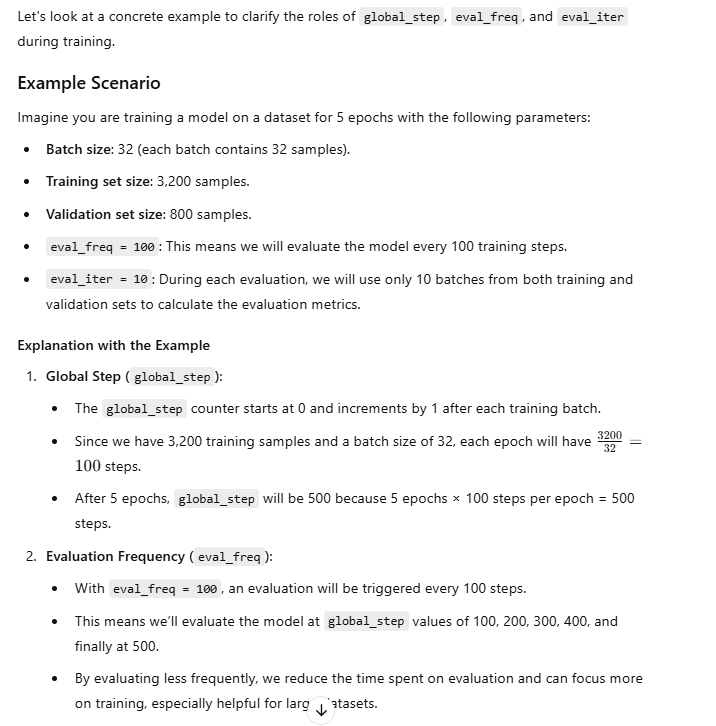

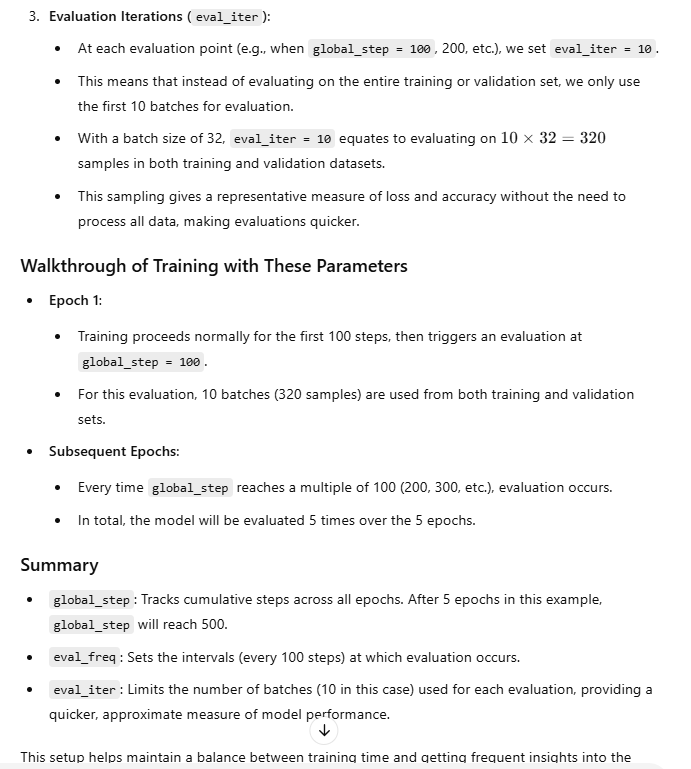

- The `evaluate_model` function used in the `train_classifier_simple` is the same as the one we used in chapter 5

This function is only used to evaluate the model’s performance on the training and validation sets. **It does not update the model's parameters.** Instead, it simply calculates the average loss for the specified number of batches (eval_iter).

```python
def evaluate_model(model, train_loader, val_loader, device, eval_iter):
    model.eval()
    with torch.no_grad():
        train_loss = calc_loss_loader(train_loader, model, device, num_batches=eval_iter)
        val_loss = calc_loss_loader(val_loader, model, device, num_batches=eval_iter)
    model.train()
    return train_loss, val_loss
```

Basically we initialize the optimizer, set the number of training epochs, and initiate the training using the train_classifier_simple function.

```python
import time

start_time = time.time()

torch.manual_seed(123)

optimizer = torch.optim.AdamW(model.parameters(), lr=5e-5, weight_decay=0.1)

num_epochs = 5

train_losses, val_losses, train_accs, val_accs, examples_seen = train_classifier_simple(
    model, train_loader, val_loader, optimizer, device,
    num_epochs=num_epochs, eval_freq=50, eval_iter=5,
)

end_time = time.time()
execution_time_minutes = (end_time - start_time) / 60
print(f"Training completed in {execution_time_minutes:.2f} minutes.")
```

```
Ep 1 (Step 000000): Train loss 4.592, Val loss 4.153
Ep 1 (Step 000050): Train loss 0.653, Val loss 0.691
Ep 1 (Step 000100): Train loss 0.721, Val loss 0.684
Ep 1 (Step 000150): Train loss 0.856, Val loss 0.690
Ep 1 (Step 000200): Train loss 0.692, Val loss 0.691
Ep 1 (Step 000250): Train loss 0.685, Val loss 0.689
Ep 1 (Step 000300): Train loss 0.832, Val loss 0.700
Ep 1 (Step 000350): Train loss 0.679, Val loss 0.685
Ep 1 (Step 000400): Train loss 0.695, Val loss 0.690
Ep 1 (Step 000450): Train loss 0.694, Val loss 0.691
Ep 1 (Step 000500): Train loss 0.842, Val loss 0.701
Ep 1 (Step 000550): Train loss 0.734, Val loss 0.716
Ep 1 (Step 000600): Train loss 0.672, Val loss 0.688
Ep 1 (Step 000650): Train loss 0.926, Val loss 0.686
Ep 1 (Step 000700): Train loss 0.691, Val loss 0.684
Ep 1 (Step 000750): Train loss 0.678, Val loss 0.690
Ep 1 (Step 000800): Train loss 0.706, Val loss 0.693
Ep 1 (Step 000850): Train loss 0.710, Val loss 0.732
Ep 1 (Step 000900): Train loss 0.703, Val loss 0.686
Ep 1 (Step 000950): Train loss 0.725, Val loss 0.685
Ep 1 (Step 001000): Train loss 0.690, Val loss 0.683
Ep 1 (Step 001050): Train loss 0.698, Val loss 0.687
Ep 1 (Step 001100): Train loss 0.704, Val loss 0.694
Ep 1 (Step 001150): Train loss 0.711, Val loss 0.698
Ep 1 (Step 001200): Train loss 0.714, Val loss 0.697
Ep 1 (Step 001250): Train loss 0.648, Val loss 0.689
Ep 1 (Step 001300): Train loss 0.687, Val loss 0.682
Ep 1 (Step 001350): Train loss 0.703, Val loss 0.713
Ep 1 (Step 001400): Train loss 0.659, Val loss 0.704
Ep 1 (Step 001450): Train loss 0.709, Val loss 0.685
Ep 1 (Step 001500): Train loss 0.667, Val loss 0.686
Ep 1 (Step 001550): Train loss 0.721, Val loss 0.685
Ep 1 (Step 001600): Train loss 0.690, Val loss 0.681
Ep 1 (Step 001650): Train loss 0.669, Val loss 0.693
Ep 1 (Step 001700): Train loss 0.678, Val loss 0.681
Ep 1 (Step 001750): Train loss 0.706, Val loss 0.681
Ep 1 (Step 001800): Train loss 0.671, Val loss 0.691
Ep 1 (Step 001850): Train loss 0.667, Val loss 0.687
Ep 1 (Step 001900): Train loss 0.667, Val loss 0.685
Ep 1 (Step 001950): Train loss 0.690, Val loss 0.688
```

[output cut: 389 more lines]

```
Ep 5 (Step 021250): Train loss 0.150, Val loss 0.144
Ep 5 (Step 021300): Train loss 0.076, Val loss 0.135
Ep 5 (Step 021350): Train loss 0.103, Val loss 0.131
Ep 5 (Step 021400): Train loss 0.155, Val loss 0.145
Ep 5 (Step 021450): Train loss 0.348, Val loss 0.146
Ep 5 (Step 021500): Train loss 0.140, Val loss 0.150
Ep 5 (Step 021550): Train loss 0.240, Val loss 0.184
Ep 5 (Step 021600): Train loss 0.188, Val loss 0.140
Ep 5 (Step 021650): Train loss 0.147, Val loss 0.142
Ep 5 (Step 021700): Train loss 0.117, Val loss 0.140
Ep 5 (Step 021750): Train loss 0.115, Val loss 0.132
Ep 5 (Step 021800): Train loss 0.195, Val loss 0.136
Ep 5 (Step 021850): Train loss 0.289, Val loss 0.134
Training accuracy: 95.00% | Validation accuracy: 97.50%
Training completed in 328.67 minutes.
```

### Plot Loss Curve: Track and plot the training and validation loss over each epoch to show the model’s learning progress.

- we use matplotlib to plot the loss function for the training and validation set

```python
import matplotlib.pyplot as plt

def plot_values(epochs_seen, examples_seen, train_values, val_values, label="loss"):
    fig, ax1 = plt.subplots(figsize=(5, 3))

    # Plot training and validation loss against epochs
    ax1.plot(epochs_seen, train_values, label=f"Training {label}")
    ax1.plot(epochs_seen, val_values, linestyle="-.", label=f"Validation {label}")
    ax1.set_xlabel("Epochs")
    ax1.set_ylabel(label.capitalize())
    ax1.legend()

    # Create a second x-axis for examples seen
    ax2 = ax1.twiny()  # Create a second x-axis that shares the same y-axis
    ax2.plot(examples_seen, train_values, alpha=0)  # Invisible plot for aligning ticks
    ax2.set_xlabel("Examples seen")

    fig.tight_layout()  # Adjust layout to make room
    plt.savefig(f"{label}-plot.pdf")
    plt.show()
```

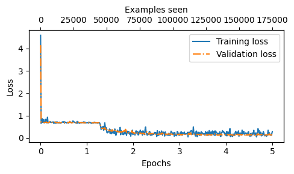

```python
epochs_tensor = torch.linspace(0, num_epochs, len(train_losses)).numpy()
examples_seen_tensor = torch.linspace(0, examples_seen, len(train_losses)).numpy()

plot_values(epochs_tensor, examples_seen_tensor, train_losses, val_losses)
```

- Above, based on the downward slope, we see that the model learns well
- Furthermore, the fact that the training and validation loss are very close indicates that the model does not tend to overfit the training data
- Similarly, we can plot the accuracy below

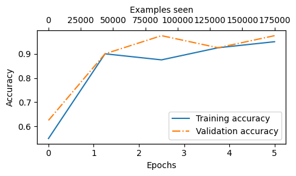

```python
epochs_tensor = torch.linspace(0, num_epochs, len(train_accs)).numpy()
examples_seen_tensor = torch.linspace(0, examples_seen, len(train_accs)).numpy()

plot_values(epochs_tensor, examples_seen_tensor, train_accs, val_accs, label="accuracy")
```

### Report Model Accuracy: Document the final accuracy achieved on each dataset (training, validation, and test)

```python
# It took too long and not able to print out so I used samples below for printing.

# train_accuracy = calc_accuracy_loader(train_loader, model, device)
# val_accuracy = calc_accuracy_loader(val_loader, model, device)
# test_accuracy = calc_accuracy_loader(test_loader, model, device)

# print(f"Training accuracy: {train_accuracy*100:.2f}%")
# print(f"Validation accuracy: {val_accuracy*100:.2f}%")
# print(f"Test accuracy: {test_accuracy*100:.2f}%")
```

```python
# Define the number of batches to sample
num_sample_batches = 20  # Adjust this to the number of batches you want to sample

# Calculate accuracy on a subset of batches
train_accuracy = calc_accuracy_loader(train_loader, model, device, num_batches=num_sample_batches)
val_accuracy = calc_accuracy_loader(val_loader, model, device, num_batches=num_sample_batches)
test_accuracy = calc_accuracy_loader(test_loader, model, device, num_batches=num_sample_batches)

print(f"Training accuracy (sampled): {train_accuracy*100:.2f}%")
print(f"Validation accuracy (sampled): {val_accuracy*100:.2f}%")
print(f"Test accuracy (sampled): {test_accuracy*100:.2f}%")
```

```
Training accuracy (sampled): 93.75%
Validation accuracy (sampled): 93.75%
Test accuracy (sampled): 92.50%
```

- We can see that the training and validation set performances are practically very similar
- However, based on the slightly lower test set performance, we can see that the model **overfits the training data to a very small degree**
- This is normal, however, and this gap could potentially be further reduced by increasing the model's dropout rate (`drop_rate`) or the `weight_decay` in the optimizer setting

[figure not shown]

- Finally, let's use the finetuned GPT model in action
- The `classify_review` function below implements the data preprocessing steps similar to the `IMDBDataset` we implemented earlier
- Then, the function returns the predicted integer class label from the model and returns the corresponding class name

```python
def classify_review(text, model, tokenizer, device, max_length=None, pad_token_id=50256):
    model.eval()

    # Prepare inputs to the model
    input_ids = tokenizer.encode(text)
    supported_context_length = model.pos_emb.weight.shape[0]
    # Note: In the book, this was originally written as pos_emb.weight.shape[1] by mistake
    # It didn't break the code but would have caused unnecessary truncation (to 768 instead of 1024)

    # Truncate sequences if they too long
    input_ids = input_ids[:min(max_length, supported_context_length)]

    # Pad sequences to the longest sequence
    input_ids += [pad_token_id] * (max_length - len(input_ids))
    input_tensor = torch.tensor(input_ids, device=device).unsqueeze(0) # add batch dimension

    # Model inference
    with torch.no_grad():
        logits = model(input_tensor)[:, -1, :]  # Logits of the last output token
    predicted_label = torch.argmax(logits, dim=-1).item()

    # Return the classified result
    return "positive" if predicted_label == 1 else "negative"
```

- Let's try it out on a few examples below

```python
text_1 = (
    "This movie is a piece of shit"
)

print(classify_review(
    text_1, model, tokenizer, device, max_length=train_dataset.max_length
))
```

```
negative
```

```python
text_2 = (
    "This movie brings me euphoria"
)

print(classify_review(
    text_2, model, tokenizer, device, max_length=train_dataset.max_length
))
```

```
positive
```

- Finally, let's save the model in case we want to reuse the model later without having to train it again

```python
# torch.save(model.state_dict(), "review_classifier.pth")
```

- Then, in a new session, we could load the model as follows

```python
# model_state_dict = torch.load("review_classifier.pth", map_location=device, weights_only=True)
# model.load_state_dict(model_state_dict)
```